# MA40198: Applied Statistical Inference

Lab 1: Minimisation using the method of Newton

Group 13: Sean Soon and Shaveen Colambage

2024-10-03

[Go back to Moodle page](https://moodle.bath.ac.uk/course/view.php?id=1836&section=11)

This lab is about gaining understanding of simple line-search optimisation methods, by coding up Newton’s method, in order to minimise negative loglikelihood functions with real data.

# Introduction

## Question 1

The Rosenbrock’s function does not correspond to any statistical model, it is simply a test function used in numerical optimisation and is given by:

$$\phi(\boldsymbol{\theta}|a,b)=\phi(\theta_1,\theta_2|a,b) =
a(\theta_2-\theta_1^2)^2 +(b-\theta_1)^2$$

Note this function is *parametrised by* `a` and `b` which are both scalars. Write an function called `rb2` which, for a given value of $\boldsymbol{\theta}^T=(\theta_1,\theta_2)$, returns a list of length 3 containing:

- `f` the function value,
- `g` the [gradient vector](https://moodle.bath.ac.uk/pluginfile.php/2633371/mod_resource/content/2/docs/06-prerequisites.html#def-gradient) (vector of partial derivatives), and
- `H` the [Hessian matrix](https://moodle.bath.ac.uk/pluginfile.php/2633371/mod_resource/content/2/docs/06-prerequisites.html#def-Hessian) (matrix of second order derivatives)

all evaluated at $\boldsymbol{\theta}$.

The following incomplete code will help you to do this task. You just need to replace `---` by the appropriate code.

```r
rb <- function(theta1=1,theta2=1,a=1,b=1) a*(theta2-theta1^2)^2+(b-theta1)^2

rb2 <- function(theta=c(1,1),a=1,b=1){

  res  <- rb(theta1 = theta[1],
             theta2 = theta[2],
             a      = a,
             b      = b)

  grad <- c( -- , -- )

  Hess <- matrix(c( --- , --- , --- , --- ),
                 nrow  = 2,
                 byrow = T)

  list(f = res,
       g = grad,
       H = Hess)

}
```

### **Solution:**

```r
rb <- function(theta1=1,theta2=1,a=1,b=1) a*(theta2-theta1^2)^2+(b-theta1)^2

rb2 <- function(theta=c(1,1),a=1,b=1) {

  res  <- rb(theta1 = theta[1],
             theta2 = theta[2],
             a      = a,
             b      = b)

  grad <- c(-4*a*theta[1]*(theta[2] - theta[1]^2) - 2*(b - theta[1]),
            2*a*(theta[2] - theta[1]^2))

  Hess <- matrix(c(-(a*(4*theta[2] - 12*theta[1]^2) - 2),
                   -4*a*theta[1],
                   -4*a*theta[1],
                   2*a),
                 nrow  = 2,
                 byrow = T)
  list(f = res,
       g = grad,
       H = Hess)

}
```

## Question 2

Create vectors of length 100 of evenly spaced $\theta_1$ and $\theta_2$ values. Let $-1 \le \theta_1 \le 1.5$ and $-0.5 \le \theta_2 \le 1.5$. Then create a matrix, `M`, whose element $i,j$ is $\phi(\theta_1^i,\theta_2^j|a,b)$, where $\theta_1^i$ and $\theta_2^j$ are elements $i$ and $j$ of the $\theta_1$, $\theta_2$ vectors created above. Use the `contour` function to produce a contour plot of the Rosenbrock’s function (with $a=10$ and $b=1$) for $-1 \le \theta_1 \le 1.5$, $-0.5 \le \theta_2 \le 1.5$. Use the `levels` argument of `contour` to set the contour levels to `c(0.03,0.1,0.3,1,3,5,10,30)`.

The minimum of the Rosenbrook function when $a=10,b=1$ can be obtained analytically to be $(\theta_1,\theta_2)=(1,1)$ (where the function takes the value of 0) which can be seen clearly from the contour plot.

The following incomplete code will help you to do this task. You just need to replace `---` by the appropriate code.

```r
theta1 <- seq(---,---,length=100)
theta2 <- seq(---,---,length=100)

M <- matrix(NA,
          nrow = 100,
          ncol = 100)

for (i in seq_along(theta1)){
  for (j in seq_along(theta2)){

    M[i,j]<-rb2(theta = c(---,---),
                a     = --- ,
                b     = ---)$---
  }
}


lev <- ---
# you can change the contour levels accordingly to the values of a and b

contour(x      = theta1,
        y      = theta2,
        z      = M,
        levels = lev,
        main   = "Contours of the Rosenbrook function a=10, b=1")

abline(h=1,lty=2,lwd=0.5)
abline(v=1,lty=2,lwd=0.5)
points(c(1,1),pch=19)
```

### **Solution**

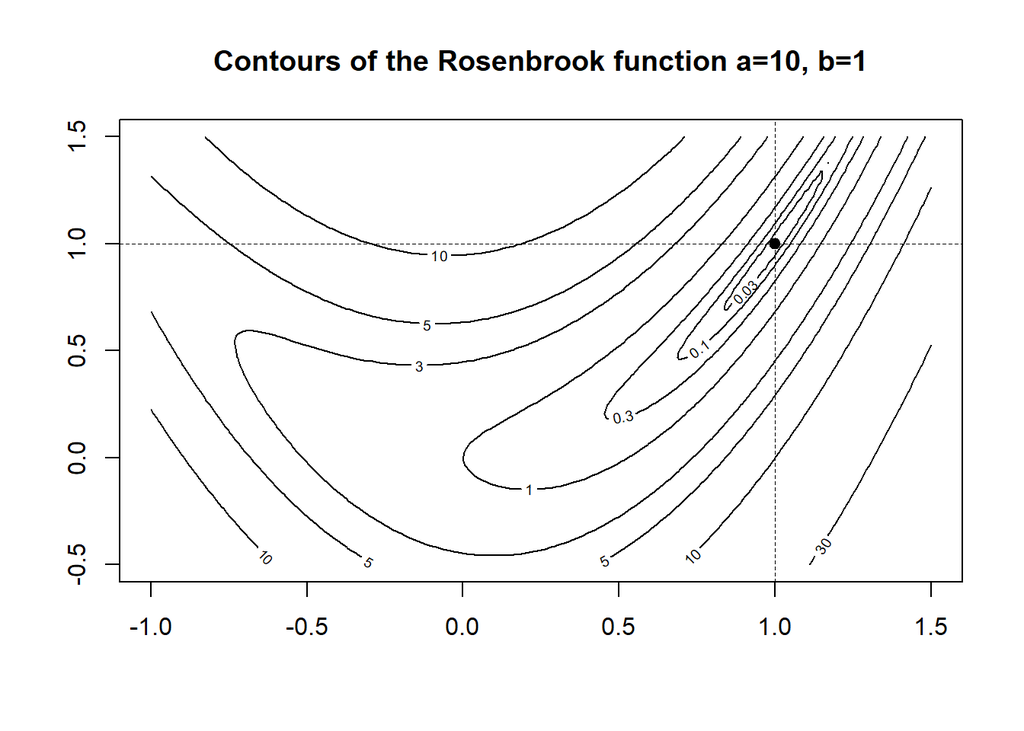

```r
theta1 <- seq(-1, 1.5, length=100)
theta2 <- seq(-0.5, 1.5, length=100)

M <- matrix(NA,
          nrow = 100,
          ncol = 100)

for (i in seq_along(theta1)){
  for (j in seq_along(theta2)){
    M[i,j]<-rb2(theta = c(theta1[i],theta2[j]),
                a     = 10 ,
                b     = 1)$f
  }
}


lev <- c(0.03,0.1,0.3,1,3,5,10,30)
# you can change the contour levels accordingly to the values of a and b

contour(x      = theta1,
        y      = theta2,
        z      = M,
        levels = lev,
        main   = "Contours of the Rosenbrook function a=10, b=1")

abline(h=1,lty=2,lwd=0.5)
abline(v=1,lty=2,lwd=0.5)
points(c(1,1),pch=19)
```

## Line-search ominimisation methods

For a given initial point $\boldsymbol{\theta}_0$. At the $k$-th iteration, a line search method computes:

- a search direction $\boldsymbol{\Delta}_k$ and then
- decides how far to move along that direction

The iteration is given by:
$$\boldsymbol{\theta}_{k+1}=\boldsymbol{\theta}_{k}+\alpha_k\,\boldsymbol{\Delta}_k
\,,\quad k=0,1,2,\ldots$$
where the scalar $\alpha_k$ is called the **step-length**. The search direction has the form:
$$\boldsymbol{\Delta}_k=-\boldsymbol{B}_{k}\,\nabla_{\!
\boldsymbol \theta}\, \phi(\boldsymbol{\theta}_{k})$$

where

- $\nabla_{\! \boldsymbol \theta}\, \phi(\boldsymbol{\theta}_{k})$ is the gradient vector evaluated at $\boldsymbol{\theta}=\boldsymbol{\theta}_k$
- $\boldsymbol{B}_{k}$ is a symmetric [positive definite matrix](https://moodle.bath.ac.uk/pluginfile.php/2633371/mod_resource/content/2/docs/06-prerequisites.html#def-pos-definite-matrix) which guarantees (as we will see in the lectures) that $\boldsymbol{\Delta}_k$ is a descent direction. An example is Newton’s direction: $\boldsymbol{B}_k=[\nabla^2_{\! \boldsymbol \theta} \phi(\boldsymbol{\theta}_{k})]^{-1}$ which is a descent direction when the Hessian $\nabla^2_{\! \boldsymbol \theta} \phi(\boldsymbol{\theta}_{k})$ is positive definite.
- For simplicity, we will set the step-length to the constant value of 1, that is $\alpha_k=1$ for all $k=0,1,2,\ldots$

### Stopping criterion

A necessary condition for $\boldsymbol{\theta}_k$ to be a local minimum is that $\nabla_{\!\boldsymbol \theta} \phi(\boldsymbol{\theta}_k)=\boldsymbol{0}_2$. If we wait for the gradient vector to become exactly the zero vector, we will be liable to wait forever. Instead, it is important to stop when the gradient is *close enough* to zero. A simple stopping criterion is
$$\|\nabla_{\!\boldsymbol \theta}\,
\phi(\boldsymbol{\theta}_{k})\|<\epsilon_a$$

where $\|\cdot\|$ is the usual vector norm and $\epsilon_a$ is the absolute tolerance which we can set to a small number for example $\epsilon_a = 10^{-6}$.

### Raw Newton’s method

Starting with $\boldsymbol \theta_0$, given a point $\boldsymbol{\theta}_k$, the next point in the Newton iteration is

$$\boldsymbol{\theta}_{k+1}=\boldsymbol{\theta}_k+\boldsymbol{\Delta}_k$$

where $\boldsymbol{\Delta}_k$ the solution of the linear system

$$\boldsymbol{H}_k\,\boldsymbol{\Delta}_k = - \boldsymbol{g}_k.$$

where

$$\boldsymbol{g}_k=\nabla_{\! \boldsymbol\theta}
\,\phi(\boldsymbol{\theta}_k)\,,\qquad \boldsymbol{H}_k=
\nabla^2_{\! \boldsymbol\theta}\, \phi(\boldsymbol{\theta}_k)$$

are the gradient vector and Hessian matrix evaluated at $\boldsymbol{\theta}_k$.

## Question 3

Using Rosenbrock’s function and starting at the point $\boldsymbol{\theta}_0=(-1/2,1/2)^T$:

- Code up Newton’s iteration with the stopping criterion described above. You may use the code below for your answer.
- Plot the trajectory of the iterations $\{\boldsymbol{\theta}_k\}$ over the contour plot of the function. The R function `arrows` may be useful for this purpose. How many iterations did it take to stop?
- At each iteration keep the value of the function and then plot the sequence of function values at the end. What is worth noting in the sequence of function values?

```r
theta  <- c(-1/2,1/2) # starting point
abstol <- 1e-6        # absolute tolerance

# evaluates objective fun, gradient and Hessian at current point

fn_pack <- rb2(theta = theta,a = 10,b = 1)
fn      <- fn_pack$f
grad    <- fn_pack$g
hess    <- fn_pack$H

######  initialisations
k             <- 1           # iterations counter
maxit         <- 1000        # maximum number of iterations
theta_seq     <- matrix(NA,nrow = maxit, ncol = 2) # parameter value iterations
theta_seq[k,] <- theta
fn_seq        <- rep(NA,maxit)    #objective function value iterations
fn_seq[k]     <- fn

while(norm(grad,type="2") > abstol){#  stopping criterion

  Delta <- -solve(hess,grad) # computes Newton direction

  # updating

  theta <- theta + Delta

  fn    <- rb2(theta = theta,a = 10,b = 1)$f
  grad  <- rb2(theta = theta,a = 10,b = 1)$g
  hess  <- rb2(theta = theta,a = 10,b = 1)$H

  k             <- k+1
  theta_seq[k,] <- theta
  fn_seq[k]     <- fn

}
```

### **Solution**

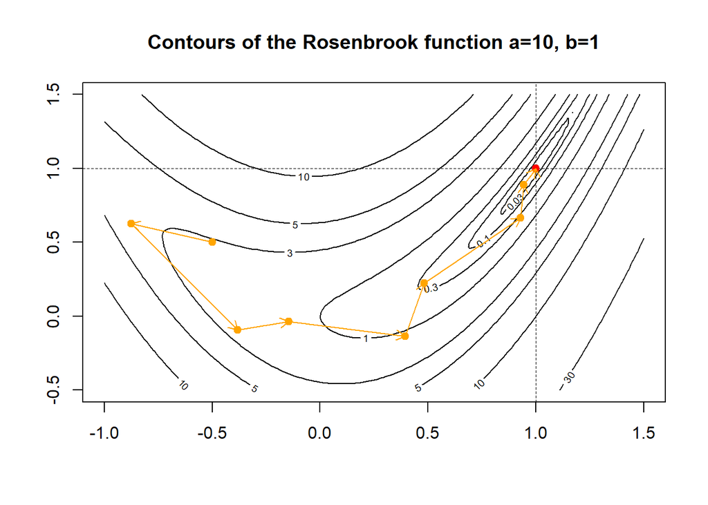

```r
theta  <- c(-1/2,1/2) # starting point
abstol <- 1e-6        # absolute tolerance

# evaluates objective fun, gradient and Hessian at current point

fn_pack <- rb2(theta = theta,a = 10,b = 1)
fn      <- fn_pack$f
grad    <- fn_pack$g
hess    <- fn_pack$H

######  initialisations
k             <- 1           # iterations counter
maxit         <- 1000        # maximum number of iterations
theta_seq     <- matrix(NA,nrow = maxit, ncol = 2) # parameter value iterations
theta_seq[k,] <- theta
fn_seq        <- rep(NA,maxit)    #objective function value iterations
fn_seq[k]     <- fn

while(norm(grad,type="2") > abstol){#  stopping criterion

  Delta <- -solve(hess,grad) # computes Newton direction

  # updating

  theta <- theta + Delta

  fn    <- rb2(theta = theta,a = 10,b = 1)$f
  grad  <- rb2(theta = theta,a = 10,b = 1)$g
  hess  <- rb2(theta = theta,a = 10,b = 1)$H

  k             <- k+1
  theta_seq[k,] <- theta
  fn_seq[k]     <- fn

}

contour(x      = theta1,
        y      = theta2,
        z      = M,
        levels = lev,
        main   = "Contours of the Rosenbrook function a=10, b=1")

abline(h=1,lty=2,lwd=0.5)
abline(v=1,lty=2,lwd=0.5)
points(x=theta_seq[,1], y=theta_seq[,2], pch=19, col='orange')
points(x=theta[1], y=theta[2], pch=19, col='red')
arrows(theta_seq[1:k-1, 1],
       theta_seq[1:k-1, 2],
       theta_seq[2:k, 1],
       theta_seq[2:k, 2],
       length=0.1,
       col='orange')
```

It took 11 iterations to stop. The sequence of function values increases initially, then decreases towards zero.

## Real example: AIDS epidemic in Belgium

The following data are reported AIDS cases in Belgium, in the early stages of an epidemic episode.

| Year | 1981 | 1982 | 1983 | 1984 | 1985 | 1986 | 1987 | 1988 | 1989 | 1990 | 1991 | 1992 | 1993 |
| --- | --- | --- | --- | --- | --- | --- | --- | --- | --- | --- | --- | --- | --- |
| Cases | 12 | 14 | 33 | 50 | 67 | 74 | 123 | 141 | 165 | 204 | 253 | 246 | 240 |

One important question, early in such epidemics, is whether control measures are beginning to have an impact or whether the disease is continuing to spread essentially unchecked. A simple model for unchecked growth leads to an *exponential increase* model. The model says that the number of cases, $\mathcal Y_i$, is an observation of an independent Poisson random variable, with expected value $\mu_i = \exp(\theta^*_1+\theta^*_2\,t_i)$ where $t_i$ is the number of years since 1980 and $\theta^*_1$ and $\theta^*_2$ are unknown parameters to be estimated by the data.

## Question 4

Define $\boldsymbol{\theta}^T=(\theta_1,\theta_2)$. Plot the contours of the negative log-likelihood of $\boldsymbol{\theta}$ in the ranges $\theta_1\in(0,4)$ and $\theta_2\in(0.1,0.4)$

### **Solution**

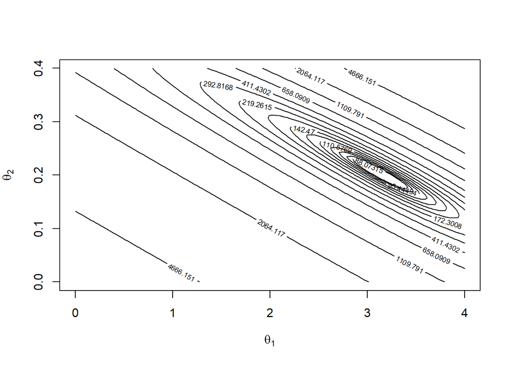

```r
x <- c(1,2,3,4,5,6,7,8,9,10,11,12,13)
y <- c(12,14,33,50,67,74,123,141,165,204,253,246,240)
Data <- data.frame(x,y)

theta1 <- seq( from = 0, to = 4,length=100)
theta2 <- seq(from = 0, to = 0.4,length=100)

neg_loglik_poisson <- function(theta1,theta2,data){
 par <- c(theta1,theta2)
 y <- data$y
 X <- model.matrix(~data$x)
 lin_pred <- X %*% par
 res <- crossprod(par,crossprod(X,y))-sum(exp(lin_pred))-sum(lgamma(y+1))
-res
}

M <- matrix(NA,
          nrow = 100,
          ncol = 100)

for (i in seq_along(theta1)){
  for (j in seq_along(theta2)){
    M[i,j]<- neg_loglik_poisson(theta1[i],theta2[j],Data)
  }
}

N_grid <- 100
theta1_grid <- seq(from = 0,to = 4, length = N_grid)
theta2_grid <- seq(from = 0,to = 0.4,length = N_grid)

neg_loglik_poisson <- Vectorize(neg_loglik_poisson,vectorize.args = c("theta1","theta2"))
nll_grid <- outer(X = theta1_grid,Y = theta2_grid,FUN = neg_loglik_poisson,data=Data)

levels <- quantile(x = nll_grid, probs = exp(seq(from = log(0.005),to = log(0.9), length = 15)))

contour(x = theta1_grid,
   y = theta2_grid,
   z = nll_grid,
   levels = levels,
   xlab = expression(theta[1]),
   ylab = expression(theta[2]))
```

## Question 5

Starting at the point $\boldsymbol{\theta}_0=(\log(5),0.5)$. Code-up Newton’s method to verify that the maximum likelihood estimator is
$$\hat{\boldsymbol{\theta}} \approx (3.14059,0.2021212)\,.$$
Plot the trajectory of the iterations $\{\boldsymbol{\theta}_k\}$ over the contour plot of the negative loglikelihood and at each iteration. How many iterations did it take to stop?

**Note** You may want to consult [Appendix B](https://moodle.bath.ac.uk/pluginfile.php/2633371/mod_resource/content/3/docs/07-optimisation-in-R.html) of the lectures notes about [Automatic differentiation in R](https://moodle.bath.ac.uk/pluginfile.php/2633371/mod_resource/content/3/docs/07-optimisation-in-R.html#sec-automatic-differentiation) for a generic code for analytical evaluation of partial derivatives in .

### **Solution**

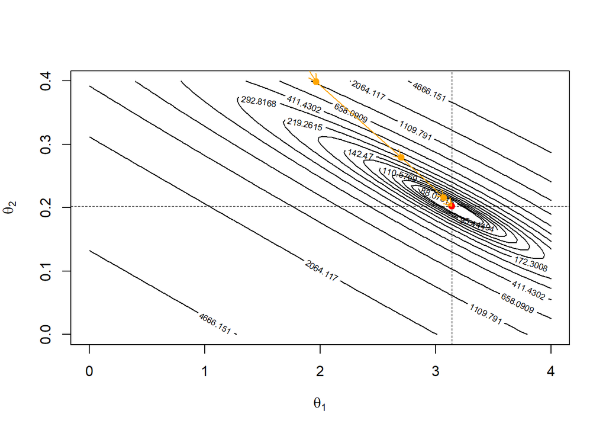

```r
theta  <- c(log(5),1/2) # starting point
abstol <- 1e-6        # absolute tolerance
loglik_expr <- expression(-exp(theta1+theta2*x)+y*(theta1+theta2*x))
neg_loglik_poisson_fn <- function(theta,data){
                         neg_loglik_poisson(theta[1],theta[2],data)
}
negloglik <- neg_loglik_poisson_fn(theta=c(log(5),0.5), data = Data)

negloglik_deriv <- deriv(expr = loglik_expr, namevec = c("theta1","theta2"),
                         function.arg = c("theta1","theta2","y","x"), hessian = TRUE)

negloglik_grad <- function(theta = c(0,0), data = 1){
                      aux <- negloglik_deriv(theta1 = theta[1],
                      theta2 = theta[2],
                      y = data$y,
                      x =data$x)

                     grad <- apply(attr(aux,"gradient"),2,sum)
                     -as.matrix(grad)
}
grad <- negloglik_grad(theta=c(log(5),0.5), data=Data)

negloglik_hess <- function(theta = c(0,0), data = 1){

                      aux <- negloglik_deriv(theta1 = theta[1],theta2 = theta[2],y = data$y,x = data$x)
                      hess <-apply(attr(aux,"hessian"),c(2,3),sum)
                      -hess
}
hess <- negloglik_hess(theta=c(log(5),0.5), data=Data)

theta  <- c(log(5),1/2)
k             <- 1           # iterations counter
maxit         <- 1000        # maximum number of iterations
theta_seq     <- matrix(NA,nrow = maxit, ncol = 2) # parameter value iterations
theta_seq[k,] <- theta
fn_seq        <- rep(NA,maxit)    #objective function value iterations
fn_seq[k]     <- negloglik

while(norm(grad,type="2") > abstol){
  Delta <- -solve(hess,grad)
  theta <- theta + Delta
  fn    <- neg_loglik_poisson_fn(theta = theta, data = Data)
  grad  <- negloglik_grad(theta = theta, data=Data)
  hess  <- negloglik_hess(theta = theta, data=Data)
  k             <- k+1
  theta_seq[k,] <- theta
  fn_seq[k]     <- fn
}

contour(x = theta1_grid,
   y = theta2_grid,
   z = nll_grid,
   levels = levels,
   xlab = expression(theta[1]),
   ylab = expression(theta[2]))

abline(h=theta[2],lty=2,lwd=0.5)
abline(v=theta[1],lty=2,lwd=0.5)
points(x=theta_seq[,1], y=theta_seq[,2], pch=19, col='orange')
points(x=theta[1], y=theta[2], pch=19, col='red')
arrows(theta_seq[1:k-1, 1],
       theta_seq[1:k-1, 2],
       theta_seq[2:k, 1],
       theta_seq[2:k, 2],
       length=0.1,
       col='orange')
```

```r
k
```

```
## [1] 7
```

It took 7 iterations to stop.